# Rによる計量政治学：練習問題の解答例

第12章 回帰分析の前提と妥当性の診断

浅野正彦, 矢内勇生

2018-11-28（改訂：2023-06-27）

## パッケージの読み込み

```r
library(tidyverse)
if (capabilities("aqua")) { # Macかどうか判定し、Macの場合のみ実行
  theme_set(theme_gray(base_size = 10, base_family = "HiraginoSans-W3"))
}
library(coefplot)
```

## Q12-1

まず、ビールの出荷量に関する分析を実行する（説明は省略する）。

```r
#dir.create("data") # dataディレクトリがないなら作る
## データを持っていないならダウンロード
#download.file(url = "https://git.io/fA6Zk",
#              destfile = "data/beer2010.csv")
Beer <- read_csv("data/beer2010.csv")  # データを読み込む
#glimpse(Beer)  # データの中身を確認
## ビールの売り上げを気温に回帰する
fit_beer <- lm(beer ~ temp, data = Beer)
summary(fit_beer)  # 結果を表示
```

```
##
## Call:
## lm(formula = beer ~ temp, data = Beer)
##
## Residuals:
##     Min      1Q  Median      3Q     Max
## -42.860 -20.242   0.882  11.037  76.939
##
## Coefficients:
##             Estimate Std. Error t value Pr(>|t|)
## (Intercept)   87.546     21.735   4.028  0.00241
## temp           2.104      1.165   1.805  0.10117
##
## Residual standard error: 31.98 on 10 degrees of freedom
## Multiple R-squared:  0.2458, Adjusted R-squared:  0.1704
## F-statistic: 3.259 on 1 and 10 DF,  p-value: 0.1012
```

この分析の残差プロットを描く。

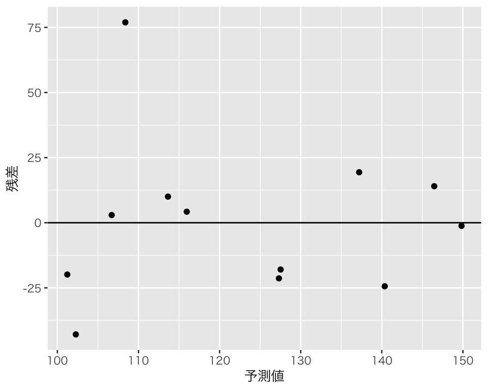

```r
res_beer <- tibble(res = fit_beer$residuals,
                   fitted = fit_beer$fitted.values) %>%
  ggplot(aes(x = fitted, y = res)) +
  geom_point() +
  geom_hline(yintercept = 0) +
  labs(x = "予測値", y = "残差")
print(res_beer)
```

はっきりとしたパタンは見られないものの、隣り合う予測値同士の残差が近いところが多いように見える。また、分散は均一ではないようにも見えるが、一つだけある外れ値を除けば、分散が均一だと言えないこともなさそうだ。標本サイズ（観測数）が12しかないので、はっきりしたことはわからない。

次に、正規QQプロットを描いてみよう。

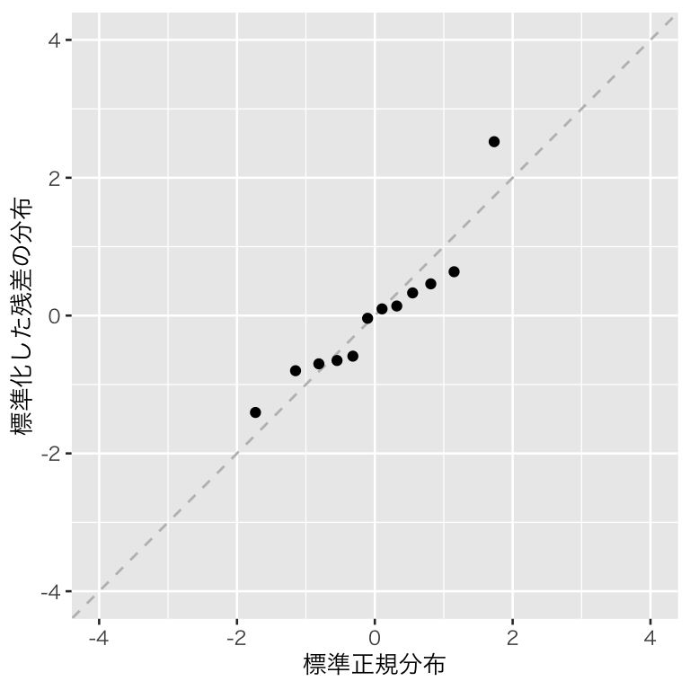

```r
## 残差を標準化する
z_res <- with(fit_beer, (residuals - mean(residuals)) / sd(residuals))
## 図を描く
qq_beer <- tibble(z_res) %>%
  ggplot(aes(sample = z_res)) +
  geom_abline(intercept = 0, slope = 1,               # 45度線
              linetype = "dashed", color = "gray") +
  geom_qq() +
  labs(x = "標準正規分布", y = "標準化した残差の分布") +
  xlim(-4, 4) + ylim(-4, 4) +
  coord_fixed()  # 横軸と縦軸を1:1にする
print(qq_beer)
```

## Q12-2

Rds形式の衆院選データ (hr-data.Rds) を読み込む。 手元にない場合はまずダウンロードする。

```r
# dir.create("data") # dataディレクトリがない場合は作る
#download.file(url = "https://git.io/fp00p",
#              destfile = "data/hr-data.Rds")
HR <- read_rds("data/hr-data.Rds")
## Rdsファイルの読み込みがうまくいかない場合は以下を実行してCSVファイルを使う
#download.file(url = "https://git.io/fxhQU",
#              destfile = "data/hr-data.csv")
#HR <- read_csv("data/hr-data.csv")
```

正しく読み込めたかどうか確認する。

```r
glimpse(HR)
```

```
## Rows: 8,803
## Columns: 22
## $ year       <dbl> 1996, 1996, 1996, 1996, 1996, 1996, 1996, 1996, 1996, 1996,…
## $ ku         <chr> "aichi", "aichi", "aichi", "aichi", "aichi", "aichi", "aich…
## $ kun        <dbl> 1, 1, 1, 1, 1, 1, 1, 2, 2, 2, 2, 2, 2, 2, 2, 3, 3, 3, 3, 3,…
## $ status     <fct> 現職, 元職, 現職, 新人, 新人, 新人, 新人, 現職, 元職, 新人,…
## $ name       <chr> "KAWAMURA, TAKASHI", "IMAEDA, NORIO", "SATO, TAISUKE", "IWA…
## $ party      <chr> "NFP", "LDP", "DPJ", "JCP", "others", "kokuminto", "indepen…
## $ party_code <dbl> 8, 1, 3, 2, 100, 22, 99, 8, 1, 3, 2, 10, 100, 99, 22, 8, 1,…
## $ previous   <dbl> 2, 3, 2, 0, 0, 0, 0, 1, 1, 0, 0, 0, 0, 0, 0, 1, 3, 1, 0, 0,…
## $ wl         <fct> 当選, 落選, 落選, 落選, 落選, 落選, 落選, 当選, 落選, 復活…
## $ voteshare  <dbl> 40.0, 25.7, 20.1, 13.3, 0.4, 0.3, 0.2, 32.9, 26.4, 25.7, 12…
## $ age        <dbl> 47, 72, 53, 43, 51, 51, 45, 51, 71, 30, 31, 44, 61, 47, 43,…
## $ nocand     <dbl> 7, 7, 7, 7, 7, 7, 7, 8, 8, 8, 8, 8, 8, 8, 8, 7, 7, 7, 7, 7,…
## $ rank       <dbl> 1, 2, 3, 4, 5, 6, 7, 1, 2, 3, 4, 5, 6, 7, 8, 1, 2, 3, 4, 5,…
## $ vote       <dbl> 66876, 42969, 33503, 22209, 616, 566, 312, 56101, 44938, 43…
## $ eligible   <dbl> 346774, 346774, 346774, 346774, 346774, 346774, 346774, 338…
## $ turnout    <dbl> 49.2, 49.2, 49.2, 49.2, 49.2, 49.2, 49.2, 51.8, 51.8, 51.8,…
## $ exp        <dbl> 9828097, 9311555, 9231284, 2177203, NA, NA, NA, 12940178, 1…
## $ expm       <dbl> 9.828097, 9.311555, 9.231284, 2.177203, NA, NA, NA, 12.9401…
## $ vs         <dbl> 0.400, 0.257, 0.201, 0.133, 0.004, 0.003, 0.002, 0.329, 0.2…
## $ exppv      <dbl> 28.341505, 26.851941, 26.620462, 6.278449, NA, NA, NA, 38.2…
## $ smd        <fct> 当選, 落選, 落選, 落選, 落選, 落選, 落選, 当選, 落選, 落選,…
## $ party_jpn  <chr> "新進党", "自民党", "民主党", "共産党", "その他", "国民党",…
```

2012年衆院選の自民党候補だけを抜き出してデータフレームを作る。

```r
LDP2012 <- filter(HR, year == 2012, party_jpn == "自民党")
```

得票率 voteshare、選挙費用 expm 、年齢 age の関係を、次の線形モデルで表す。
$$得票率_i =
\beta_0 + \beta_1 選挙費用_i + \beta_2 年齢_i + \epsilon_i.$$

母数について、以下の2組の仮説を立てる。

1. 係数を包括的に検定するための仮説
- 帰無仮説：$\beta_1 = \beta_2 = 0$
- 対立仮説：$\beta_1$と$\beta_2$のうち、少なくとも一つは0ではない
2. 係数を個別に検定するための仮説（$k \in \{1, 2\}$）
- 帰無仮説：$\beta_k = 0$
- 対立仮説：$\beta_k \neq 0$

有意水準を5% (0.05) に設定し、回帰分析でこのモデルの母数である $\beta_0$、$\beta_1$、$\beta_2$ の推定と検定を行う。

```r
fit_q12 <- lm(voteshare ~ expm + age, data = LDP2012)
summary(fit_q12)
```

```
##
## Call:
## lm(formula = voteshare ~ expm + age, data = LDP2012)
##
## Residuals:
##     Min      1Q  Median      3Q     Max
## -23.392  -8.661  -1.616   5.744  39.938
##
## Coefficients:
##             Estimate Std. Error t value Pr(>|t|)
## (Intercept) 25.95257    3.60177   7.206 5.30e-12
## expm         0.63259    0.18087   3.498 0.000545
## age          0.26858    0.06361   4.223 3.26e-05
##
## Residual standard error: 11.94 on 282 degrees of freedom
##   (4 observations deleted due to missingness)
## Multiple R-squared:  0.1071, Adjusted R-squared:  0.1007
## F-statistic: 16.91 on 2 and 282 DF,  p-value: 1.164e-07
```

包括的な仮説から検定しよう。上で示された結果のうち、最後の行にある$F$統計量の$p値$ を見ると、$1.16 \times 10^{-7} < 0.05$ だから、有意水準5%で帰無仮説を棄却する。すなわち、$\beta_1$と$\beta_2$のうち、少なくとも一方は0ではない。言い換えると、（**上で想定したモデルが正しいなら**）選挙費用と年齢のうち少なくとも一方は得票率に影響を与える。

次に、係数を個別に検定しよう。まず、過去の選挙費用 (expm) の係数の$p$値は、$0.000545 < 0.05$ だから、有意水準5%で帰無仮説を棄却する。すなわち、選挙費用は得票率に影響を与える。$\beta_1$の推定値は約$0.63$だから、年齢を一定に保つと、選挙費用が100万円増えるごとに、得票率は平均すると$0.63$パーセントポイントずつ上昇すると考えられる。この選挙における自民党候補の選挙費用の標準偏差は、3.94百万円である。選挙費用が400万円（おおよそ1標準偏差分）異なると、$2.53$パーセントポイント得票率に差が出るということなので、この効果は実質的にはそれほど重要ではなさそうだ。

この分析結果を図にまとめる。

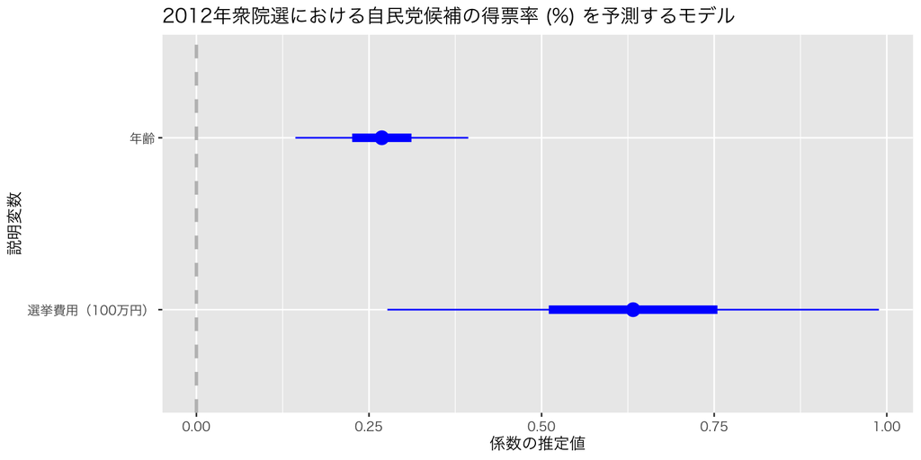

```r
coefs_q12 <- coefplot(
  model = fit_q12,    # 図示するモデルを指定
  intercept = FALSE,  # 切片を表示しない
  pointSize = 4,      # 点の大きさを4に
  ## 内側の線を50%信頼区間にする。既定値は1（「点推定値±1標準誤差」）
  innerCI = qt(df = summary(fit_q12)$df[2],
               p = 0.25, lower.tail = FALSE),
  lwdInner = 2.5,     # 内側の線の太さを2.5に
  ## 外側の線を95%信頼区間にする。既定値は2（「点推定値±2標準誤差」）
  outerCI = qt(df = summary(fit_q12)$df[2],
               p = 0.025, lower.tail = FALSE),
  lwdOuter = 0.5,     # 外側の線の太さを0.5に
  ## 説明変数を日本語で表示する
  newNames = list(expm = "選挙費用（100万円）", age = "年齢"),
  xlab = "係数の推定値",
  ylab = "説明変数",
  title = "2012年衆院選における自民党候補の得票率 (%) を予測するモデル"
)
print(coefs_q12)
```

この図が推定結果をまとめている。縦軸にはモデルに含まれる説明変数が並んでいる。横軸は、係数の推定値の大きさを表している。図中の点は、各説明変数の係数の点推定値である。また、水平に引かれた線は、内側の太い線が50パーセント信頼区間、外側の細い線が95パーセント信頼区間である。いずれの変数についても、95パーセント信頼区間がゼロを跨いでいないので、推定された効果は5%の有意水準で統計的に有意であることがわかる。この分析の標本サイズは285、自由度調整済み決定係数は0.1である。

### Q12-2-2

上のモデルの残差プロットを作る。

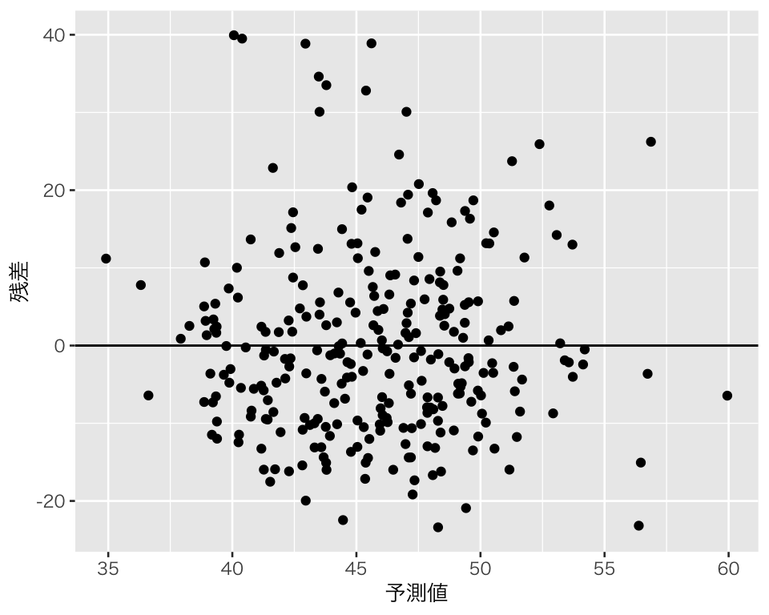

```r
res_ldp <- tibble(res = fit_q12$residuals,
                  fitted = fit_q12$fitted.values) %>%
  ggplot(aes(x = fitted, y = res)) +
  geom_point() +
  geom_hline(yintercept = 0) +
  labs(x = "予測値", y = "残差")
print(res_ldp)
```

特に目立ったパタンはなさそうである。残差の分散は、予測値が小さいとき（予測得票率が40%以下）にそれ以外の場合よりも小さく、誤差の分散は均一ではないかもしれない。

最後に、正規QQプロットで誤差の分布を診断する。

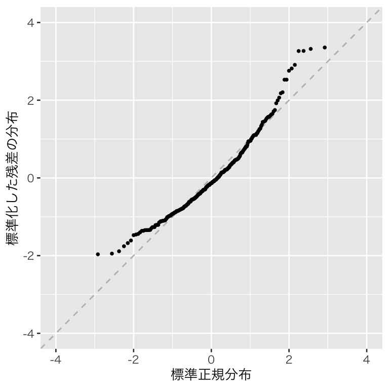

```r
## 残差を標準化する
z_res <-  with(fit_q12, (residuals - mean(residuals)) / sd(residuals))
## 図を描く
qq_ldp <- tibble(z_res) %>%
  ggplot(aes(sample = z_res)) +
  geom_abline(intercept = 0, slope = 1,               # 45度線
              linetype = "dashed", color = "gray") +
  geom_qq(pch = 16, size = 1) +
  labs(x = "標準正規分布", y = "標準化した残差の分布") +
  xlim(-4, 4) + ylim(-4, 4) +
  coord_fixed()  # 横軸と縦軸を1:1にする
print(qq_ldp)
```

分布の端で残差が45度線から外れており、誤差の分布が正規分布ではない可能性が示唆される。